# PML prediction

## R Markdown

We are performing an analysis on the classe variable using the accelerometers variables (12 in total - belt, forearm, arm, dumbell and for each of those 3 axes - x, y, z). First thing to note is that classe is a categorical value, therefore classical linear and non-linear model are not a good choice. Here a good choice seems something like a random forest

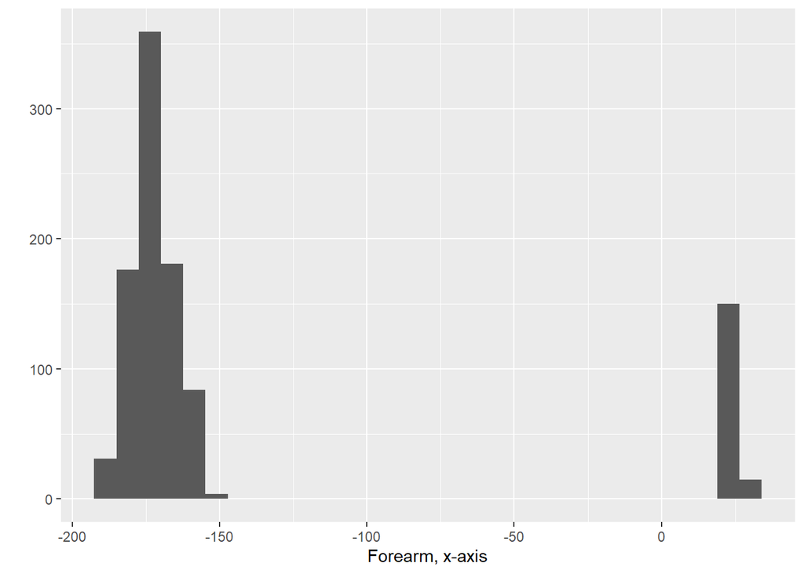

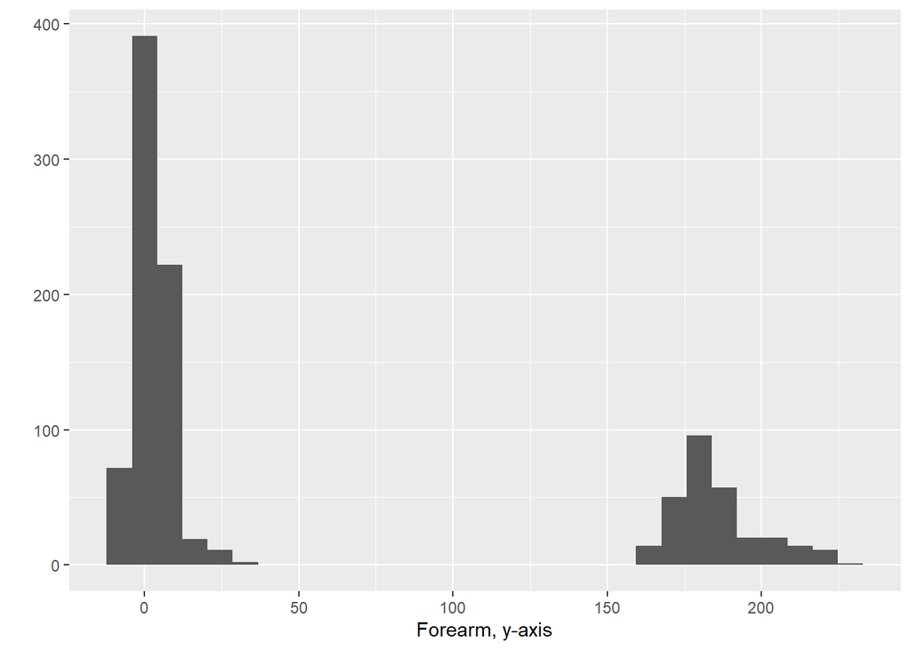

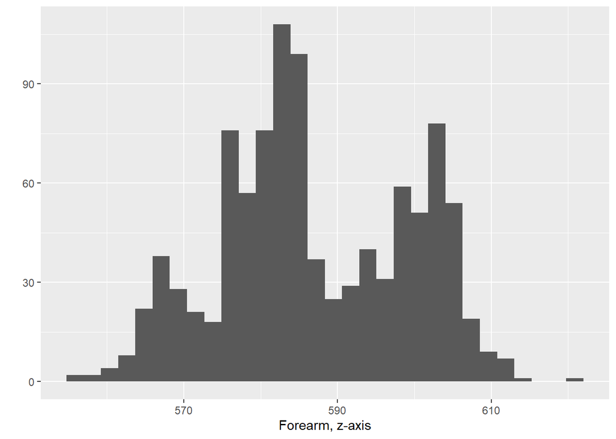

Let’s build a model based on regression trees. We could furthermore use PCA preprocessing, where only 5 components would suffice to explain 80 percent variability but in the interest of using all the variables, we will skip this.

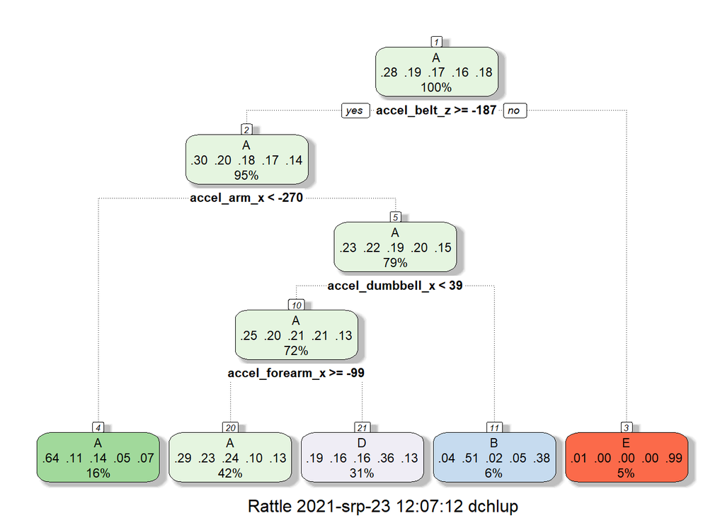

```r
model <- train(classe ~. , method = "rpart", data = training1)

fancyRpartPlot(model$final)
```

Let’s now try random forests.

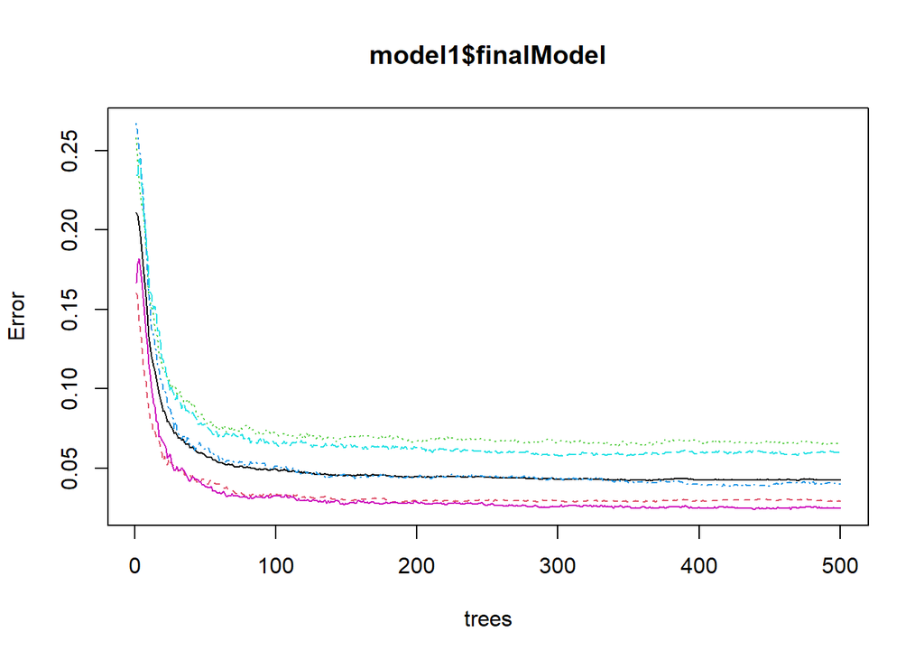

```r
model1 <- train(classe ~. , method = "rf", data = training1)

plot(model1$finalModel)
```

It seems that random forest explains the data very well. Therefore, we will use this model for predictions. Following are the predicted results.

```r
testing <- read.csv("https://d396qusza40orc.cloudfront.net/predmachlearn/pml-testing.csv")
ind1 <- c(which(startsWith(colnames(training), "accel")))
testing1 <- testing[,ind1]
pred <- predict(model1, testing1)
pred
```

```
##  [1] B A C A A E D B A A B C B A E E A B B B
## Levels: A B C D E
```